# Cantilever beam modelling: single beam. Reduced dimensionality of the calibrations parameters

Olga Egorova

19 April 2021

We consider here a toy example of a 3-layer beam with 2 interfaces, clamped at one end, with no extra load – just gravity. **Angle misalignments are assumed to occur in the top and bottom layers rather than in all three.**

```r
knitr::opts_chunk$set(echo = TRUE)
knitr::opts_knit$set(root.dir = normalizePath(".")) # set the working directory
```

The following code specifies the virtual environment where the computer model (pyComp) lives, and the paths to the python scripts producing outputs for (1) generating “artificial” data (e.g. using finer grid) and (2) simulations. The paths are to be changed(!)

If no python code is to be run, please ignore this chuck of code.

First we set up the parameters – the number of beams that we have “observed” (here – it is $1$), number of data points observed and the number of simulations.

```r
n_beam = 1           # number of "true" underlying theta-s
n_data = 10          # number of data points
n_simulations = 30   # number of simulations
```

1. Data

Picking the “true” displacements theta-s (choosing at random in the region $[-\pi/30, \pi/30]$), running the FE model and saving the displacements.Middle layer displacement is set to $0$. If no python code is run – please go straight to the next chunk.

```r
# Choosing the true theta within the region of -/+(pi/30)
theta_data = data.table(matrix(runif(n = 3*n_beam, min = -pi/30, max = pi/30), nrow = n_beam))
colnames(theta_data) = c("theta_1", "theta_2", "theta_3")
theta_data$theta_2 = 0
theta_data
```

| theta_1 | theta_2 | theta_3 |
| --- | --- | --- |
| 0.001235035 | 0 | 0.005260996 |

```r
############################################
# Load the FE model for data generation
############################################
source_python(python_data)
dt_coords = read.table("out/obs_coords.csv", header = FALSE, sep = ",",  col.names = c("x", "y", "z"))

# Obtain displacements across all observational points
dt_displacements = cbind(dt_coords, data.frame("D" = rep(0, nrow(dt_coords))))
for (d in 1:n_beam){
 dt_displacements[, ncol(dt_coords)+d] =
   myModel$solve(baseAngles + as.numeric(theta_data[d,]), TRUE, iterativeSolver = FALSE)
}

write.csv(theta_data, "out/theta_data.csv", row.names = FALSE)
write.csv(dt_displacements, "out/dt_displacements.csv", row.names = FALSE)
```

Data generation.

Given the “true” $\theta$-s and the displacement values, we assume normal independent errors with zero mean and variance $\sigma^2_e$ (set up in the following chunk of code). The variance is constant across the observational points – it is attributed to the variability occurring from the observational process rather than from the location of the points or any other properties.

|  | x | y | z | D | logD | data |
| --- | --- | --- | --- | --- | --- | --- |
| 4 | 0.3020134 | 0.0000000 | 0.64 | -0.0005378294 | -7.527969162 | -7.527969168 |
| 5 | 0.4026846 | 0.0000000 | 0.64 | -0.0018300209 | -6.303427887 | -6.303427885 |
| 6 | 0.5033557 | 0.0000000 | 0.64 | -0.0037168999 | -5.594865314 | -5.594865309 |
| 7 | 0.6040268 | 0.0000000 | 0.64 | -0.0061680916 | -5.088365787 | -5.088365776 |
| 8 | 0.7046980 | 0.0000000 | 0.64 | -0.0091651280 | -4.692349427 | -4.692349428 |
| 9 | 0.8053691 | 0.0000000 | 0.64 | -0.0126957443 | -4.366488433 | -4.366488448 |
| 10 | 0.9060403 | 0.0000000 | 0.64 | -0.0167506340 | -4.089319172 | -4.089319175 |
| 11 | 1.0067114 | 0.0000000 | 0.64 | -0.0213217789 | -3.848026246 | -3.848026231 |
| 12 | 1.1073826 | 0.0000000 | 0.64 | -0.0264016997 | -3.634326887 | -3.634326887 |
| 13 | 1.2080537 | 0.0000000 | 0.64 | -0.0319831002 | -3.442547634 | -3.442547614 |

[output cut: 990 more lines]

The $\mbox{n_data}$ points are chosen from all the observed ones as a $\mbox{maximin}$ design. In case of any errors/warnings – might be worth to install an earlier version of the package $\mbox{maximin}$ (as above). The specific vector of indexes on the code chunk below is given for the purposes of reproducibility.

|  | x | y | z | data |
| --- | --- | --- | --- | --- |
| 32 | 3.1208054 | 0.0000000 | 0.64 | -1.4991376 |
| 275 | 12.4832215 | 0.1052632 | 0.64 | 0.8778008 |
| 402 | 10.1677852 | 0.2105263 | 0.64 | 0.5736416 |
| 1412 | 6.1409396 | 0.9473684 | 0.64 | -0.2507870 |
| 1791 | 14.0939597 | 1.1578947 | 0.64 | 1.0473408 |
| 1956 | 0.5033557 | 1.3684211 | 0.64 | -4.8170384 |

2. Simulations

Running the simulations: choosing $\theta$-s as a space-filling design ($\mbox{mogp_emulator\$LatinHypercubeDesign}$ function in Python) from a “feasible” region: $\pm \pi/30$; the middle layer angle misalignment is set to $0$.

$\mbox{theta_simulation}$ contains the values of $\theta$-s used for simulations, corresponding to each column of the simulation outputs $\mbox{dt_all_simulation}$.

If no Python code is run – please go to the next chunk.

[output not shown]

```r
write.csv(theta_simulation, "out/theta_simulation.csv", row.names = FALSE)
write.csv(dt_all_simulation, "out/dt_all_simulation.csv", row.names = FALSE)

head(theta_simulation)

head(dt_all_simulation)
```

```
             [,1]          [,2]          [,3]          [,4]          [,5]          [,6]          [,7]          [,8]          [,9]         [,10]
[1,]  0.000000000  0.0000000000  0.000000e+00  0.0000000000  0.0000000000  0.000000e+00  0.0000000000  0.0000000000  0.0000000000  0.0000000000
[2,]  0.000106768 -0.0002057152  7.889416e-05  0.0002373838 -0.0007444606 -6.503672e-05 -0.0001261738 -0.0004147624 -0.0002743891 -0.0002514401
[3,] -0.001468528 -0.0020886265 -1.495438e-03 -0.0011354458 -0.0032982088 -1.807833e-03 -0.0018395562 -0.0026809447 -0.0022793583 -0.0022303140
[4,] -0.005509655 -0.0063990954 -5.471288e-03 -0.0048555650 -0.0085014696 -5.984747e-03 -0.0058291074 -0.0076821168 -0.0068034009 -0.0067234465
[5,] -0.011801008 -0.0128632722 -1.161732e-02 -0.0107286461 -0.0160190957 -1.234028e-02 -0.0118359880 -0.0151216446 -0.0135628819 -0.0134500717
[6,] -0.020290523 -0.0214009011 -1.987375e-02 -0.0187125426 -0.0257417405 -2.080304e-02 -0.0197861123 -0.0249074888 -0.0224730968 -0.0223268538
             [,11]         [,12]         [,13]         [,14]        [,15]         [,16]         [,17]         [,18]         [,19]         [,20]
[1,]  0.0000000000  0.0000000000  0.0000000000  0.000000e+00  0.000000000  0.0000000000  0.0000000000  0.000000e+00  0.0000000000  0.0000000000
[2,] -0.0003113986 -0.0003547003  0.0001954891 -4.491731e-05 -0.000562680 -0.0004293915 -0.0001752218  7.244165e-06 -0.0002917763 -0.0005368865
[3,] -0.0024790791 -0.0025776443 -0.0012133926 -1.674498e-03 -0.003008895 -0.0027449481 -0.0021565383 -1.643944e-03 -0.0023421919 -0.0029229903
[4,] -0.0074057541 -0.0075781677 -0.0049473398 -5.577397e-03 -0.008241858 -0.0078651242 -0.0068116062 -5.699230e-03 -0.0069612142 -0.0080328952
[5,] -0.0148191589 -0.0150772809 -0.0107958747 -1.150378e-02 -0.015946117 -0.0154992229 -0.0138851558 -1.191403e-02 -0.0138630446 -0.0155520145
[6,] -0.0246382166 -0.0249904777 -0.0187089193 -1.938380e-02 -0.026020033 -0.0255568262 -0.0233052417 -2.022213e-02 -0.0229619195 -0.0253799474
             [,21]        [,22]        [,23]         [,24]         [,25]         [,26]         [,27]         [,28]         [,29]         [,30]
[1,]  0.0000000000  0.000000000  0.000000000  0.0000000000  0.0000000000  0.000000e+00  0.0000000000  0.0000000000  0.0000000000  0.0000000000
[2,] -0.0001274659 -0.000129572 -0.000421134 -0.0006987923 -0.0005076801 -6.579569e-05 -0.0003455121 -0.0001190883 -0.0002698602 -0.0001633185
[3,] -0.0019690102 -0.001944489 -0.002580614 -0.0032564240 -0.0027696010 -1.875326e-03 -0.0025154784 -0.0018686281 -0.0023566694 -0.0020991576
[4,] -0.0063067403 -0.006203733 -0.007269629 -0.0085507581 -0.0075875855 -6.244565e-03 -0.0073735777 -0.0059674131 -0.0071243075 -0.0066392358
[5,] -0.0128768532 -0.012642644 -0.014188024 -0.0162488237 -0.0146519765 -1.292581e-02 -0.0146308293 -0.0121540318 -0.0142966626 -0.0135200477
[6,] -0.0216041553 -0.021185451 -0.023243268 -0.0262414059 -0.0238657505 -2.185157e-02 -0.0241993276 -0.0203537293 -0.0237919824 -0.0226663915
```

Read the simulation output for all the observational points and choose the ones to use in the modelling.

The final dataset $\mbox{dt_simulation}$ contains $n_simulation$ rows of location coordinates, $\theta_1$, $\theta_3$ and simulation outputs.

| x | y | z | theta_1 | theta_3 | s |
| --- | --- | --- | --- | --- | --- |
| 1.418919 | 0.0000000 | 0.64 | -0.05502287 | -0.09240256 | -3.1309212 |
| 4.864865 | 0.0000000 | 0.64 | -0.03228576 | 0.06217932 | -0.6968788 |
| 7.702703 | 0.0000000 | 0.64 | -0.07130426 | -0.03342942 | 0.1244509 |
| 8.918919 | 0.0000000 | 0.64 | -0.09569777 | -0.09853249 | 0.3728050 |
| 11.756757 | 0.0000000 | 0.64 | 0.09544282 | 0.09918610 | 0.8198994 |
| 10.743243 | 0.2222222 | 0.64 | -0.04878801 | 0.01207807 | 0.6500558 |

In case the previous chunk is not run – read the simulation inputs (location coordinates and $\theta$-s) and outputs.

```r
dt_simulation = read.table("out/dt_simulation.csv", header = TRUE, sep = ",")
XT_sim = dt_simulation[, 1:(ncol(dt_simulation) -1)]

head(dt_simulation)
```

|  | x | y | z | theta_1 | theta_3 | s |
| --- | --- | --- | --- | --- | --- | --- |
| 1 | 1.418919 | 0.0000000 | 0.64 | -0.05502287 | -0.09240256 | -3.1309212 |
| 2 | 4.864865 | 0.0000000 | 0.64 | -0.03228576 | 0.06217932 | -0.6968788 |
| 3 | 7.702703 | 0.0000000 | 0.64 | -0.07130426 | -0.03342942 | 0.1244509 |
| 4 | 8.918919 | 0.0000000 | 0.64 | -0.09569777 | -0.09853249 | 0.3728050 |
| 5 | 11.756757 | 0.0000000 | 0.64 | 0.09544282 | 0.09918610 | 0.8198994 |
| 6 | 10.743243 | 0.2222222 | 0.64 | -0.04878801 | 0.01207807 | 0.6500558 |

```r
head(XT_sim)
```

|  | x | y | z | theta_1 | theta_3 |
| --- | --- | --- | --- | --- | --- |
| 1 | 1.418919 | 0.0000000 | 0.64 | -0.05502287 | -0.09240256 |
| 2 | 4.864865 | 0.0000000 | 0.64 | -0.03228576 | 0.06217932 |
| 3 | 7.702703 | 0.0000000 | 0.64 | -0.07130426 | -0.03342942 |
| 4 | 8.918919 | 0.0000000 | 0.64 | -0.09569777 | -0.09853249 |
| 5 | 11.756757 | 0.0000000 | 0.64 | 0.09544282 | 0.09918610 |
| 6 | 10.743243 | 0.2222222 | 0.64 | -0.04878801 | 0.01207807 |

The following sets up the rstan environment, and the parameters for the stan model.

```r
## Set up the environment
## https://betanalpha.github.io/assets/case_studies/gaussian_processes.html#21_Simulating_From_A_Gaussian_Process

# set stan to execute multiple Markov chains in parallel
rstan_options(auto_write = TRUE)
options(mc.cores = parallel::detectCores())
parallel:::setDefaultClusterOptions(setup_strategy = "sequential")

util = new.env()
par(family="CMU Serif", las=1, bty="l", cex.axis=1, cex.lab=1, cex.main=1,
    xaxs="i", yaxs="i", mar = c(5, 5, 3, 5))

## https://github.com/adChong/bc-stan/blob/master/src/main.R

# get dimensions of dataset
p = ncol(dt_coords)     # number of input factors
q = ncol(XT_sim) - p    # number of calibration parameters
n = nrow(dt_data)       # sample size of observed field data
m = nrow(XT_sim)        # sample size of computer simulation data

# extract data from dt_data and dt_simulation
y = dt_data[, p+1]                   # observed output
eta = dt_simulation[, p+q+1]         # simulation output
xf = dt_data[,1:p]                   # observed input
xc = as.matrix(XT_sim[, 1:p])        # simulation input
tc = as.matrix(XT_sim[,(p+1):(p+q)])       # calibration parameters input

x_pred = xf                     # design points for predictions
n_pred = nrow(x_pred)           # number of predictions

# standardisation of output y and eta w.r.t eta
eta_mu = mean(eta, na.rm = TRUE) # mean value
eta_sd = sd(eta, na.rm = TRUE)   # standard deviation
eta = (eta - eta_mu) / eta_sd

y_mu = mean(y, na.rm = TRUE) # mean value
y_sd = sd(y, na.rm = TRUE)   # standard deviation
y = (y - eta_mu) / eta_sd

# Put design points xf and xc on [0,1]
x = rbind(as.matrix(xf), as.matrix(xc))
for (i in (1:ncol(x))){
  x_min = min(x[,i], na.rm = TRUE)
  x_max = max(x[,i], na.rm = TRUE)
  xf[,i] = (xf[,i] - x_min) / (x_max - x_min)
  xc[,i] = (xc[,i] - x_min) / (x_max - x_min)
  x_pred[,i] = (x_pred[,i] - x_min) / (x_max - x_min)
}

# Put calibration parameters t on domain [0,1]
for (j in (1:ncol(tc))){
  tc_min = min(tc[,j], na.rm = TRUE)
  tc_max = max(tc[,j], na.rm = TRUE)
  tc[,j] = (tc[,j] - tc_min) / (tc_max - tc_min)
}

# create data as list for input to Stan
stan_data = list(n=n, m=m, n_pred=n_pred, p=p, y=y, q=q, eta=eta,
                  xf=as.matrix(xf), xc=as.matrix(xc),
                  x_pred=as.matrix(x_pred), tc=as.matrix(tc))
```

Fit a calibration model with the discrepancy term $: $y(x) = \eta(x,t) + \delta(x) + \varepsilon$. Make sure that the priors in the .stan file are specified for the correct number of $\theta$-s Fitting can take a couple of minutes – that does depend on the number of data and simulation points.

```r
# run model in stan
fit = stan(
  file = "/Users/olga/work/CerTest/CerTest_notes/Cantilever_beam/Single_beam_two_thetas/Bayesian_calibration_GPs.stan",
  data = stan_data,
  iter = 4000,
  chains = 3)
```

```
starting worker pid=72352 on localhost:11108 at 10:34:19.913
starting worker pid=72366 on localhost:11108 at 10:34:20.161
starting worker pid=72380 on localhost:11108 at 10:34:20.400
```

[output not shown]

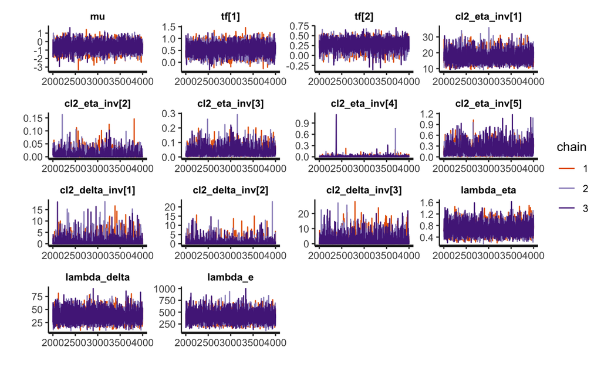

```r
# plot traceplots, excluding warm-up
stan_trace(fit, pars = c("mu","tf", "cl2_eta_inv", "cl2_delta_inv",
                         "lambda_eta", "lambda_delta", "lambda_e"))  #"mu",
```

```r
# summarize results
print(fit, pars = c("mu","tf", "cl2_eta_inv", "cl2_delta_inv",
                    "lambda_eta", "lambda_delta", "lambda_e"))
```

```
Inference for Stan model: Bayesian_calibration_GPs.
3 chains, each with iter=4000; warmup=2000; thin=1;
post-warmup draws per chain=2000, total post-warmup draws=6000.

                   mean se_mean     sd   2.5%    25%    50%    75%  97.5% n_eff Rhat
mu                -0.59    0.01   0.57  -1.71  -0.98  -0.59  -0.20   0.52  4936 1.00
tf[1]              0.55    0.00   0.23   0.10   0.40   0.55   0.70   1.00  5357 1.00
tf[2]              0.28    0.00   0.13   0.00   0.21   0.29   0.36   0.50  2698 1.00
cl2_eta_inv[1]    17.58    0.08   3.54  11.75  15.00  17.26  19.78  25.57  1815 1.00
cl2_eta_inv[2]     0.01    0.00   0.01   0.00   0.00   0.01   0.01   0.04  1366 1.00
cl2_eta_inv[3]     0.03    0.00   0.03   0.00   0.01   0.02   0.04   0.11  1079 1.00
cl2_eta_inv[4]     0.01    0.00   0.03   0.00   0.00   0.00   0.01   0.04  1602 1.00
cl2_eta_inv[5]     0.17    0.00   0.14   0.02   0.06   0.13   0.24   0.52   998 1.01
cl2_delta_inv[1]   0.67    0.02   1.54   0.00   0.01   0.09   0.56   5.02  5695 1.00
cl2_delta_inv[2]   0.47    0.02   1.25   0.00   0.00   0.05   0.33   3.82  5309 1.00
cl2_delta_inv[3]   1.64    0.04   2.84   0.00   0.04   0.46   1.98  10.03  6531 1.00
lambda_eta         0.65    0.00   0.20   0.33   0.51   0.63   0.77   1.11  4556 1.00
lambda_delta      36.28    0.14  10.88  17.87  28.46  35.23  42.93  60.13  6382 1.00
lambda_e         395.88    1.62 113.55 204.92 314.67 386.96 465.72 642.29  4894 1.00

Samples were drawn using NUTS(diag_e) at Mon Apr 19 10:35:39 2021.
For each parameter, n_eff is a crude measure of effective sample size,
and Rhat is the potential scale reduction factor on split chains (at
convergence, Rhat=1).
```

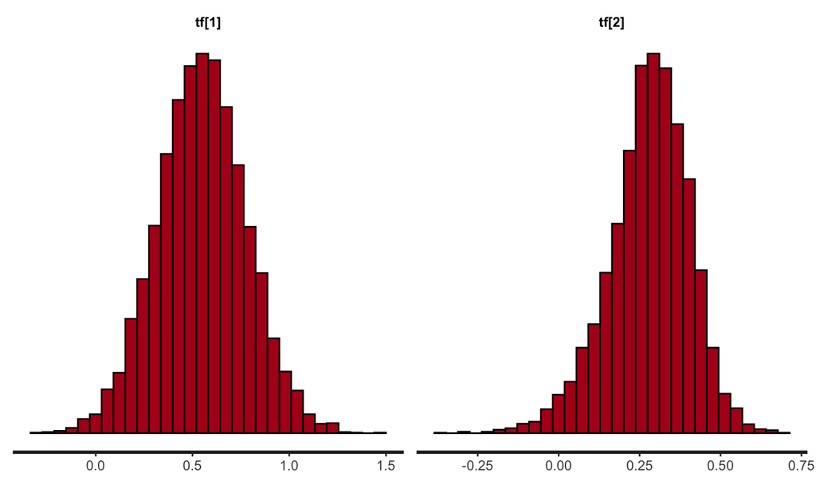

```r
# posterior probability distribution of tf
stan_hist(fit, pars = c("tf"))
```

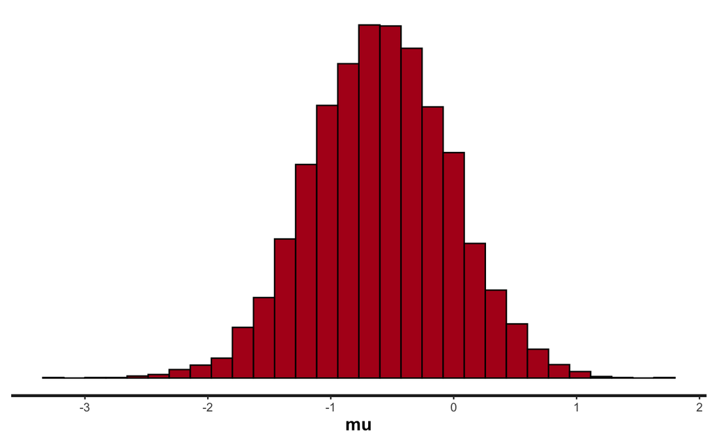

```r
stan_hist(fit, pars = c("mu"))
```

```r
# True scaled theta-s
c((theta_data[1,1]- min(XT_sim[,p+1]))/(max(XT_sim[,p+1]) - min(XT_sim[,p+1])),
  (theta_data[1,3]- min(XT_sim[,p+2]))/(max(XT_sim[,p+2]) - min(XT_sim[,p+2])))
```

```
[1] 0.5037534 0.5249556
```

```r
theta_data/(pi/180)
```

| theta_1 | theta_2 | theta_3 |
| --- | --- | --- |
| 0.0707623 | 0 | 0.3014329 |

```r
NA
```

Look at pairs and triplets of theta posteriors – in contrast with marginals observed on the histograms before.

```r
df_of_draws = as.data.table(fit)               # nrow == number of chains x number of iterations
setnames(df_of_draws, old = c("tf[1]", "tf[2]"),
         new = c("tf1","tf2"))
head(df_of_draws)
```

| mu | tf1 | tf2 | rho_eta[1] | rho_eta[2] | rho_eta[3] | rho_eta[4] | rho_eta[5] | rho_delta[1] | rho_delta[2] | rho_delta[3] | lambda_eta | lambda_delta | lambda_e | cl2_eta_inv[1] | cl2_eta_inv[2] | cl2_eta_inv[3] | cl2_eta_inv[4] | cl2_eta_inv[5] | cl2_delta_inv[1] | cl2_delta_inv[2] | cl2_delta_inv[3] | lp__ |
| --- | --- | --- | --- | --- | --- | --- | --- | --- | --- | --- | --- | --- | --- | --- | --- | --- | --- | --- | --- | --- | --- | --- |
| -0.7582190 | 0.4983281 | 0.5279081 | 0.0342790565 | 0.9948176 | 0.9952638 | 0.9971272 | 0.9899084 | 0.9956429 | 0.9120387 | 0.9857240 | 0.6605932 | 37.26239 | 468.0147 | 13.49288 | 0.02078336 | 0.018989933 | 0.011507643 | 0.04057165 | 0.01746635 | 3.682915e-01 | 0.0575157227 | 108.9396 |
| -0.6948228 | 0.1623942 | 0.1922625 | 0.0168730334 | 0.9975266 | 0.9981903 | 0.9993442 | 0.9474203 | 0.9826563 | 0.9997395 | 0.7163040 | 0.6146619 | 36.06567 | 332.1710 | 16.32815 | 0.00990579 | 0.007245447 | 0.002623925 | 0.21604990 | 0.06998352 | 1.041947e-03 | 1.3346023649 | 114.4783 |
| -0.4124491 | 0.2590385 | 0.2035248 | 0.0115696551 | 0.9973175 | 0.9973441 | 0.9994912 | 0.9277948 | 0.9658110 | 0.9999975 | 0.9927517 | 0.6586399 | 35.57563 | 410.0113 | 17.83748 | 0.01074439 | 0.010637892 | 0.002035734 | 0.29977863 | 0.13914859 | 1.005362e-05 | 0.0290987550 | 112.1473 |
| -1.0005831 | 0.4372580 | 0.2303948 | 0.0116989214 | 0.9960207 | 0.9976953 | 0.9984599 | 0.9902600 | 0.9627308 | 0.9999640 | 0.6359105 | 0.7251193 | 51.10909 | 416.0266 | 17.79303 | 0.01594887 | 0.009229362 | 0.006165083 | 0.03915099 | 0.15192586 | 1.441862e-04 | 1.8107897837 | 115.0356 |
| -0.2856507 | 0.2815550 | 0.2137449 | 0.0008144006 | 0.9942812 | 0.9976839 | 0.9994818 | 0.9751906 | 0.5458422 | 0.4665906 | 0.9999710 | 0.9552437 | 27.39205 | 374.6884 | 28.45223 | 0.02294094 | 0.009275246 | 0.002073352 | 0.10048952 | 2.42170135 | 3.049212e+00 | 0.0001160019 | 109.3544 |
| 0.2548571 | 0.2008858 | 0.2005039 | 0.0023954936 | 0.9961804 | 0.9974719 | 0.9996973 | 0.9698095 | 0.9486571 | 0.9838953 | 0.9993714 | 0.6288052 | 43.78027 | 305.2668 | 24.13666 | 0.01530770 | 0.010125178 | 0.001210993 | 0.12262241 | 0.21083167 | 6.494299e-02 | 0.0025151869 | 111.3623 |

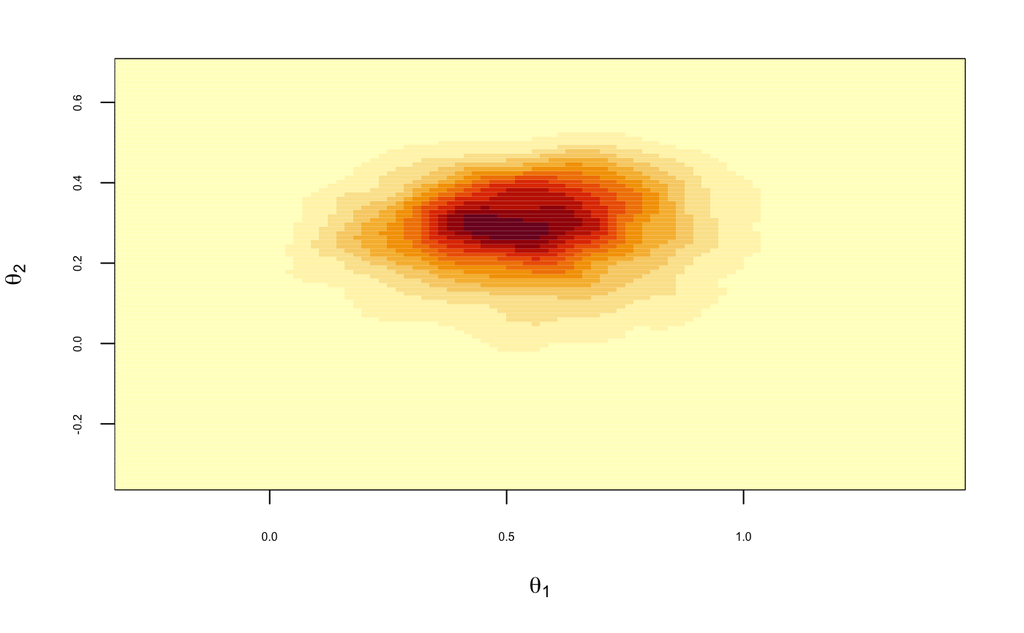

```r
library(MASS)

par(cex.axis = 0.5)
k1 <- kde2d(df_of_draws$tf1, df_of_draws$tf2, n=100)
image(k1, xlab = expression(theta[1]), ylab = expression(theta[2]))
```